# Chocolates Exploration by Dlaivison R. Silva

> The Objective of this exploration is to identify the cocoa market and its variances. The consumption of chocolate in the world is increasing every year. Several people prefers also best quality chocolates instead of popular brands. Similar to wine and cofee the cocoa also has different types of beans and flavors. The current dataset shows ratings of the cocoa quality and its origin.

# Univariate Plots Section

```
## 'data.frame':    1795 obs. of  9 variables:
##  $ CompanyÂ...Maker.if.known.      : Factor w/ 416 levels "A. Morin","Acalli",..: 1 1 1 1 1 1 1 1 1 1 ...
##  $ Specific.Bean.Origin.or.Bar.Name: Factor w/ 1039 levels "\"heirloom\", Arriba Nacional",..: 15 494 68 16 813 175 288 923 805 731 ...
##  $ REF                             : int  1876 1676 1676 1680 1704 1315 1315 1315 1319 1319 ...
##  $ Review.Date                     : int  2016 2015 2015 2015 2015 2014 2014 2014 2014 2014 ...
##  $ Cocoa.Percent                   : Factor w/ 45 levels "100%","42%","46%",..: 14 21 21 21 21 21 21 21 21 21 ...
##  $ Company.Location                : Factor w/ 60 levels "Amsterdam","Argentina",..: 19 19 19 19 19 19 19 19 19 19 ...
##  $ Rating                          : num  3.75 2.75 3 3.5 3.5 2.75 3.5 3.5 3.75 4 ...
##  $ Bean.Type                       : Factor w/ 42 levels "","Â ","Amazon",..: 2 2 2 2 2 10 2 10 10 2 ...
##  $ Broad.Bean.Origin               : Factor w/ 101 levels "","Â ","Africa, Carribean, C. Am.",..: 70 80 80 80 57 93 18 93 93 57 ...
```

```
##  CompanyÂ...Maker.if.known.   Specific.Bean.Origin.or.Bar.Name
##  Soma    :  47              Madagascar        :  57
##  Bonnat  :  27              Peru              :  45
##  Fresco  :  26              Ecuador           :  42
##  Pralus  :  25              Dominican Republic:  37
##  A. Morin:  23              Venezuela         :  21
##  Arete   :  22              Chuao             :  19
##  (Other) :1625              (Other)           :1574
##       REF        Review.Date   Cocoa.Percent Company.Location
##  Min.   :   5   Min.   :2006   70%    :672   U.S.A. :764
##  1st Qu.: 576   1st Qu.:2010   75%    :222   France :156
##  Median :1069   Median :2013   72%    :189   Canada :125
##  Mean   :1036   Mean   :2012   65%    : 78   U.K.   : 96
##  3rd Qu.:1502   3rd Qu.:2015   80%    : 72   Italy  : 63
##  Max.   :1952   Max.   :2017   74%    : 50   Ecuador: 54
##                                (Other):512   (Other):537
##      Rating                     Bean.Type            Broad.Bean.Origin
##  Min.   :1.000   Â                   :887   Venezuela         :214
##  1st Qu.:2.875   Trinitario          :419   Ecuador           :193
##  Median :3.250   Criollo             :153   Peru              :165
##  Mean   :3.186   Forastero           : 87   Madagascar        :145
##  3rd Qu.:3.500   Forastero (Nacional): 52   Dominican Republic:141
##  Max.   :5.000   Blend               : 41   Â                 : 73
##                  (Other)             :156   (Other)           :864
```

# Cocoa rating distribution scale

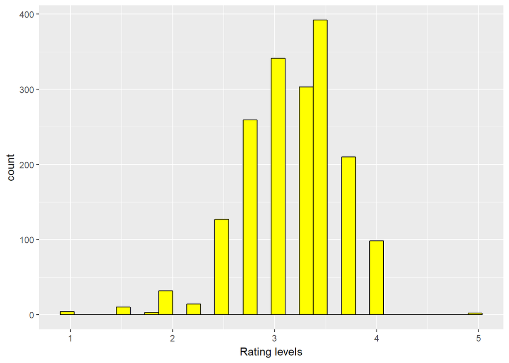

# Percentage levels of chocolate sold in the world

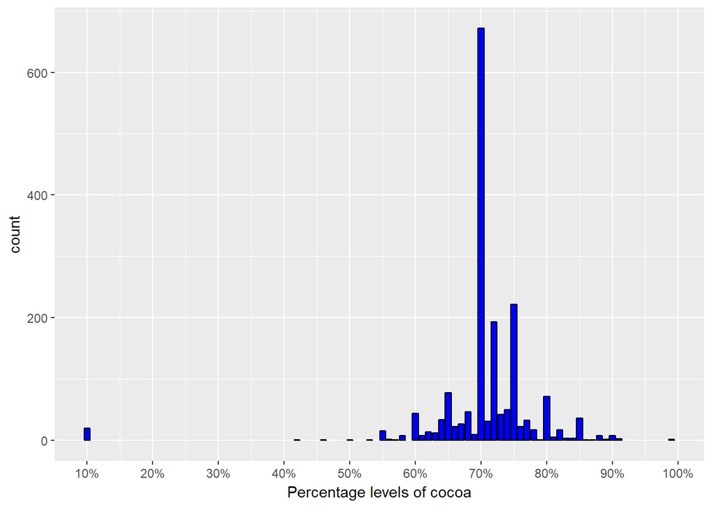

> Above the percentage levels of cocoa in the manufacturing.It shows that the concentration of 70% is by far the more produced in the world. This is because the 70% of cocoa is also used in other areas such pastry and ice cream industry

# Main chocolate company locations

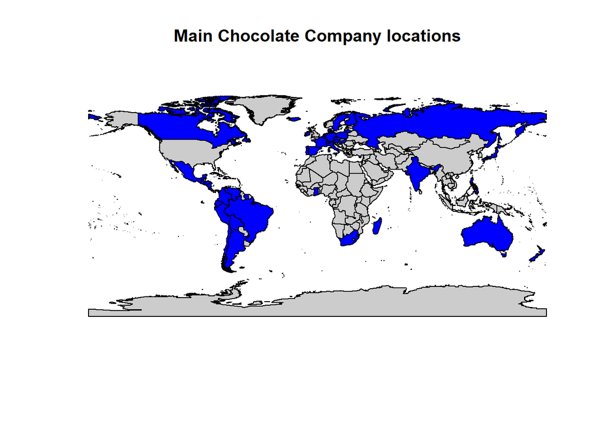

```
## integer(0)
```

> The map above shows the location of the main chocolate manufactures in the world.

# Main Cocoa bean exporters

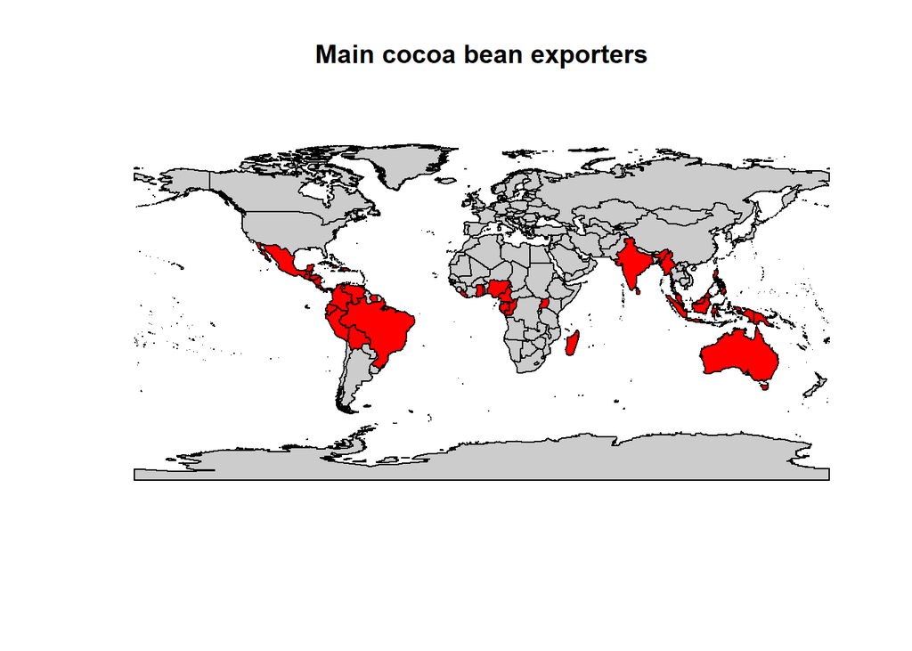

```
## integer(0)
```

> As showed above the main cocoa producers are countries located closer to Ecuador where the cocoa developes better

# The top Manufacturing countries with the best rating chocolate (rating >4)

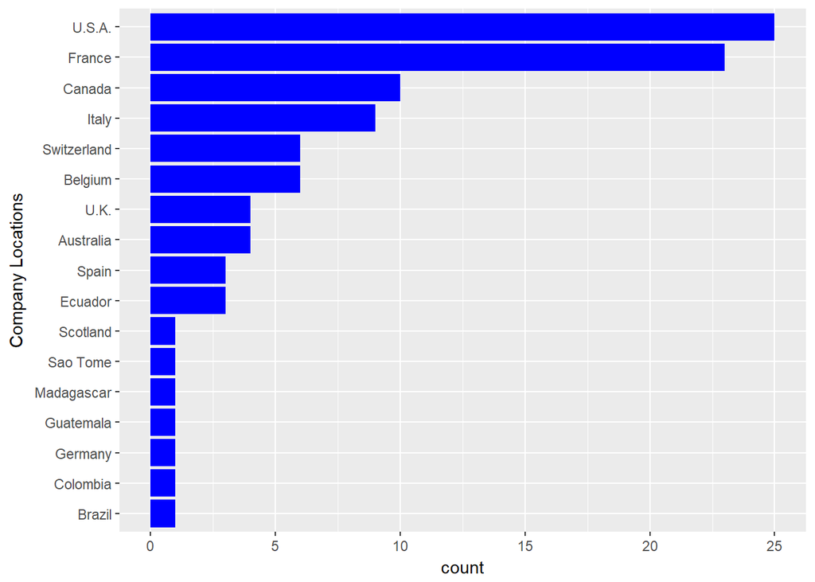

> This plot shows that considering the most of all top rated chocolate (above 4) have their locations in USA , France, Italy, Canada, Belgium and Switzerland. There are more american chocolate companies that produces a very good rated chocolated than other countries.

# The top Manufacturing countries with the lower rating Chocolate

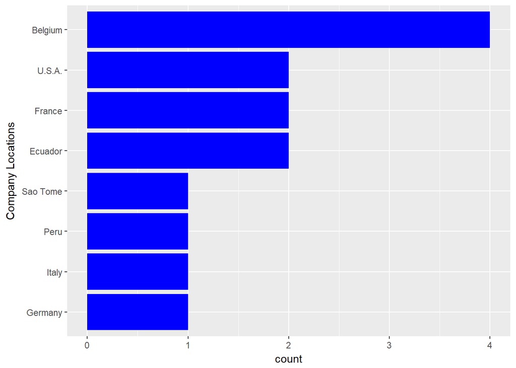

> This plot shows that for companies with lower rating level, there are also USA, France and Belgium companies. But there is something here that must be also considered. Sometimes the type of cocoa produced is not at high quality because its destination is to be used not as decoration, eg: chocolate sprinkles. So it could explain why some countries with high qualified rates appears also here.

# Bean Type distribution

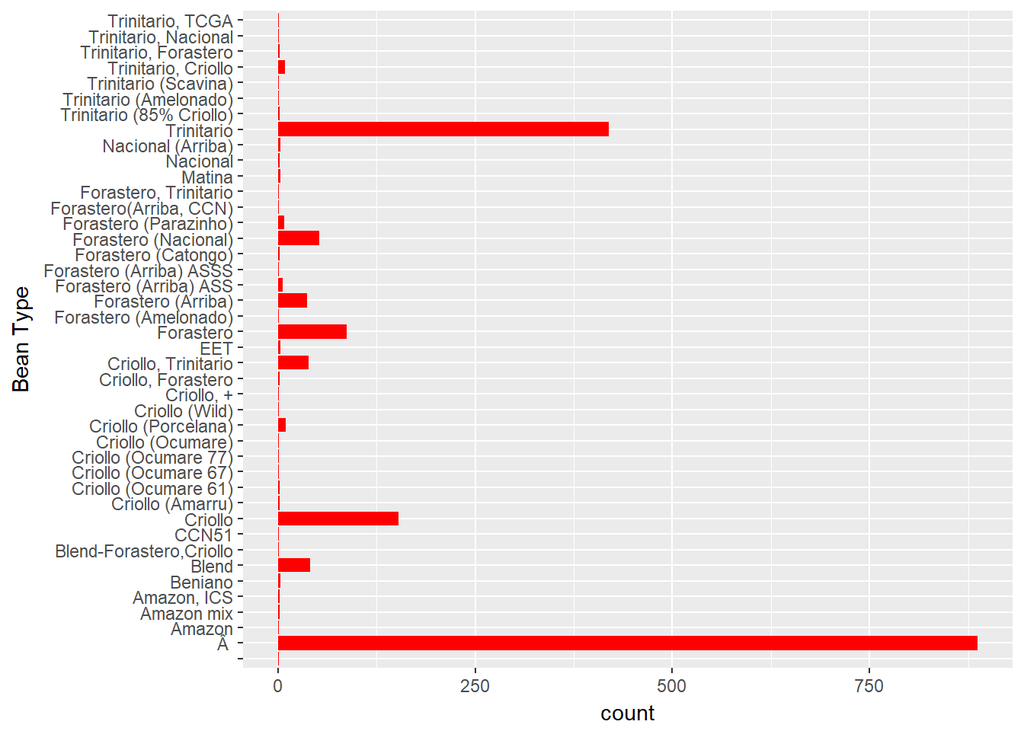

> This plot shows the Bean type sold in the world

# Main manufacturing companies

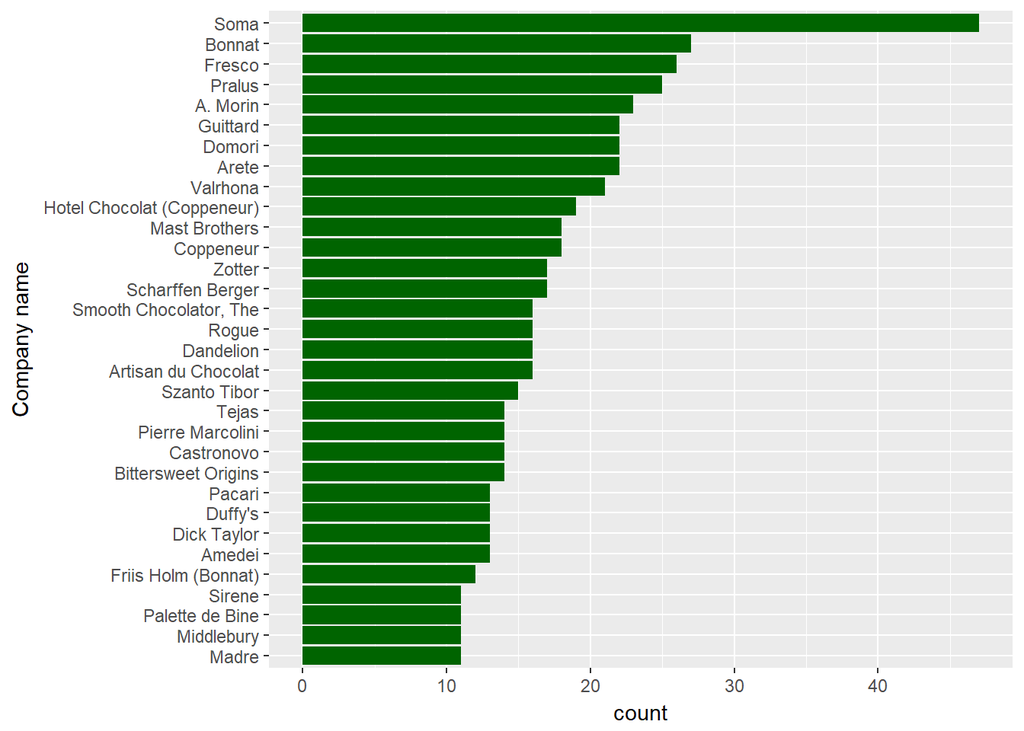

> In the plot above SOMA (Canadian company) is the main producer of the samples collected in this research.

# Univariate Analysis

### What is the structure of your dataset?

> The dataset contains data about the main chocolate producers, main cocoa bean exporters and the quality of beans/chocolate classified in an international rate.

### What is/are the main feature(s) of interest in your dataset?

> To understand and classify the best chocolate beans and relate them to the main manufacturers. The main question to answer here is “Does the best bean means the best chocolate” ?

### What other features in the dataset do you think will help support your into your feature(s) of interest?

> Based on the content of the dataset I also will determine if some companies still produces the best rating chocolates in the world or if there will be new companies in the field.

### Did you create any new variables from existing variables in the dataset?

> yes. I’ve created a varible called Bean.filter to adjust some repeatable cocoa beans types.

### Of the features you investigated, were there any unusual distributions?

> So far the distributions seems to be according what I expected.

# Percentage chocolate levels x Rating

> In order to perform such analysis I’ve created another variable called Bean.Filter where I have filtered the values from the Beans just to specify one specie.

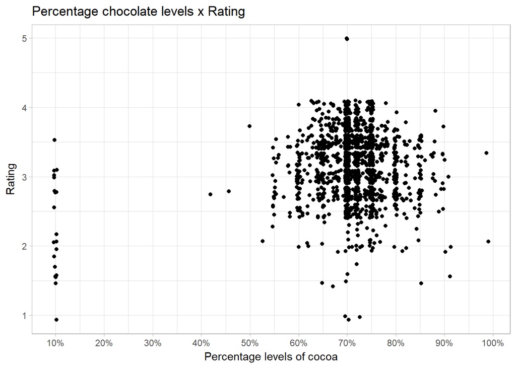

> This chart shows the percentage levels of cocoa vs the Rating. There is a concentration of points around the percentage of 70%. This means the percentage of 70% is the most important and qualified for chocolate processing

# The best Manufacturing countries based on the mean Rating

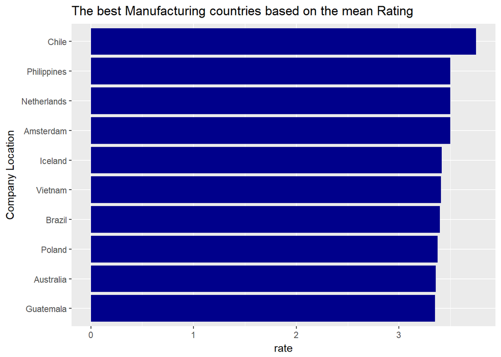

> Plotting the mean value we can find an interesting fact. Chile although not participating in the top 5 best level rating, at mean values is the country that produces the best rating values.

# Top 10 cocoa best bean producers (non Manufactures). Producers with the best cocoa beans

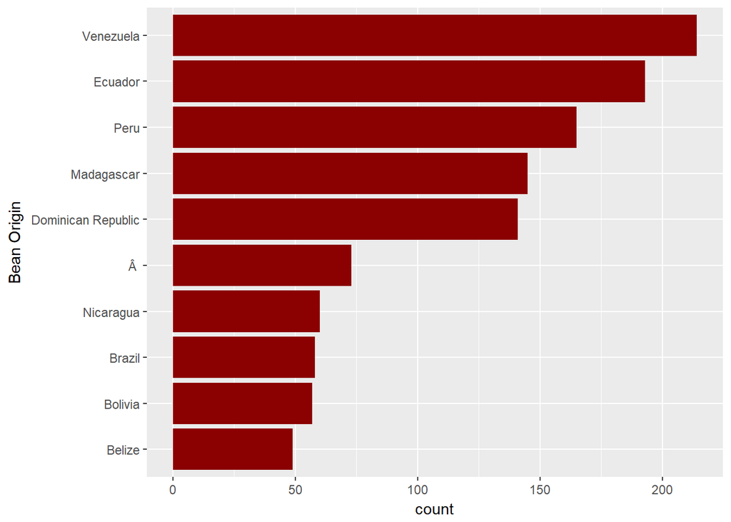

# The worst Manufacturing countries based on mean Rating

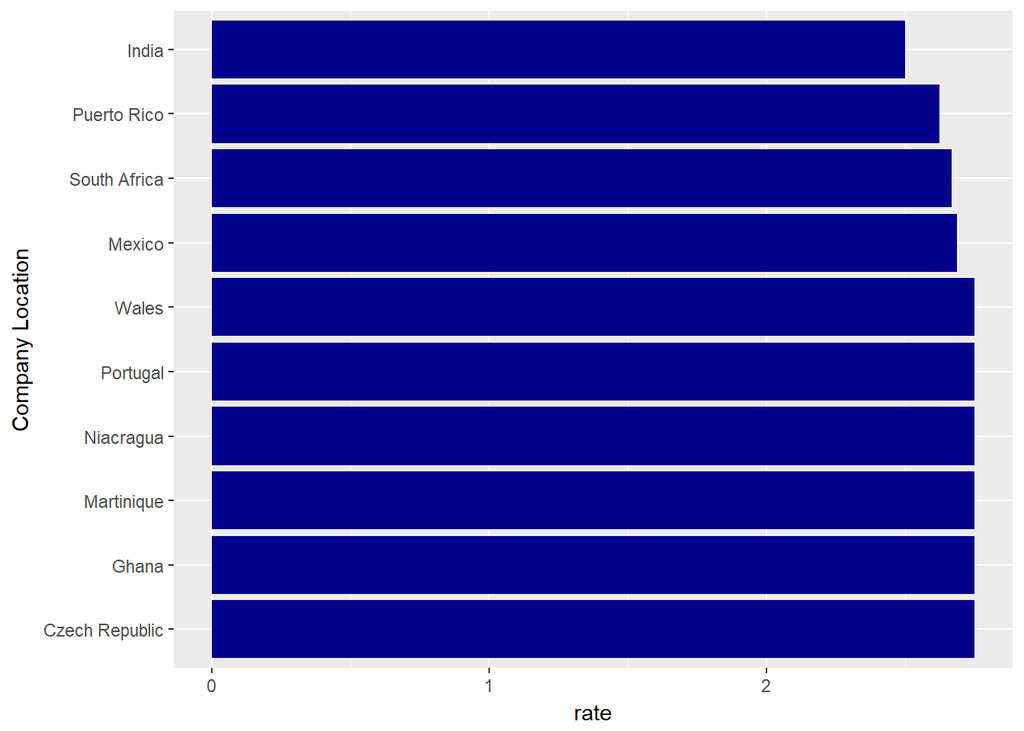

> This plot shows countries where the mean rate is considered low

# The best bean types based on the mean rating values

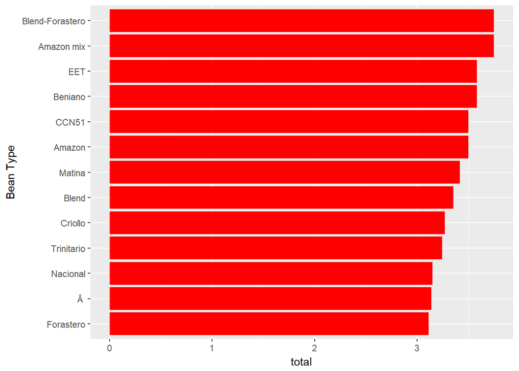

> According to the plot the best bean types based on mean rating values are “Blend-Forasteiro” and “Amazon mix”

# Percentage levels x Rating

> In order to perceive better some relations , the category of Cocoa Percent will be update to the following values .Less_than_70 (x < 60) .Around_70 (60<=x<=80) .More_than_70 (x > 80 )

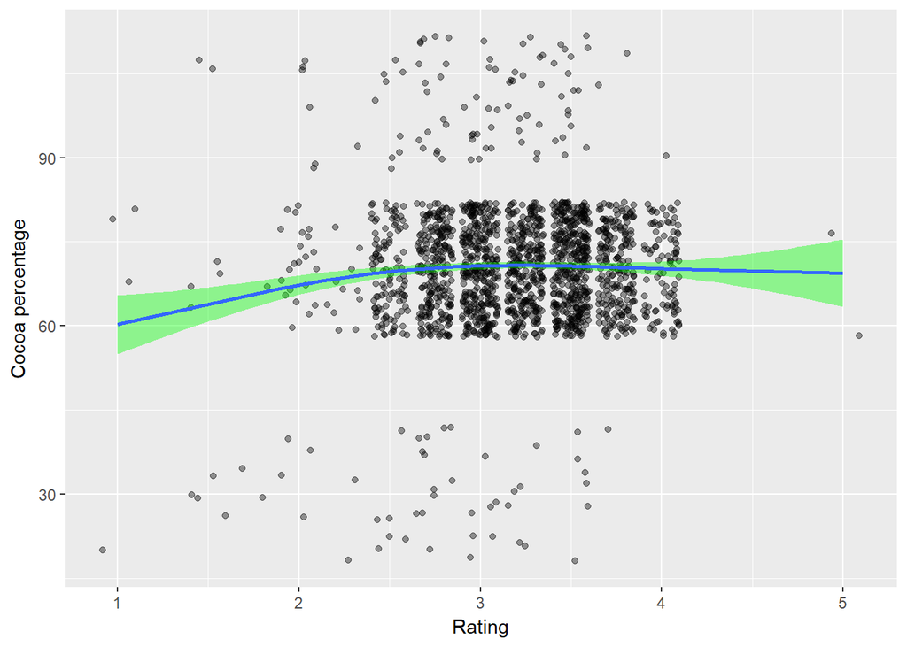

```
##
##  Pearson's product-moment correlation
##
## data:  as.numeric(cho$level == 30) and cho$Rating
## t = -7.9285, df = 1793, p-value = 3.865e-15
## alternative hypothesis: true correlation is not equal to 0
## 95 percent confidence interval:
##  -0.2283652 -0.1389595
## sample estimates:
##       cor
## -0.184043
```

```
##
##  Pearson's product-moment correlation
##
## data:  as.numeric(cho$level == 70) and cho$Rating
## t = 8.6614, df = 1793, p-value < 2.2e-16
## alternative hypothesis: true correlation is not equal to 0
## 95 percent confidence interval:
##  0.1555755 0.2444005
## sample estimates:
##       cor
## 0.2003998
```

```
##
##  Pearson's product-moment correlation
##
## data:  as.numeric(cho$level == 100) and cho$Rating
## t = -4.5644, df = 1793, p-value = 5.35e-06
## alternative hypothesis: true correlation is not equal to 0
## 95 percent confidence interval:
##  -0.15268257 -0.06120968
## sample estimates:
##        cor
## -0.1071729
```

> For values around 70% the correlation has a value closer to 0.2.

# Main manufacturing companies based on Rating

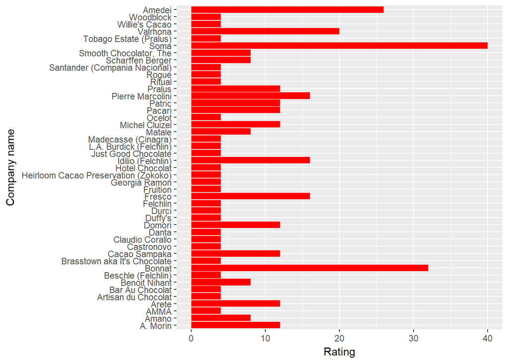

> Based in the samples collected, company SOMA has the majority of chocolate rated better. It could be related to the quantity of samples collected.

# Main manufacturing companies based on Mean Rating

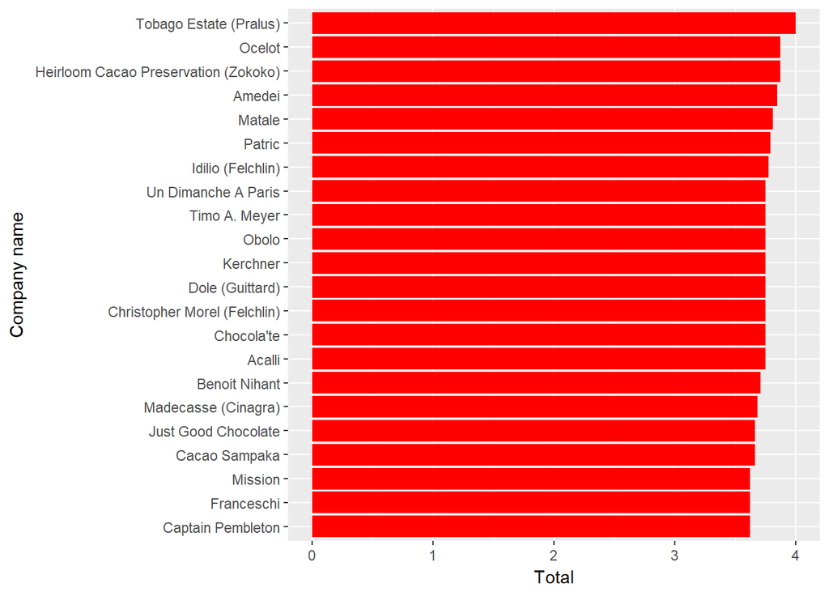

> Considering the mean value, the company Tobago Estate has the better ratings.

# Bivariate Analysis

### Talk about some of the relationships you observed in this part of the investigation. How did the feature(s) of interest vary with other features in the dataset?

> I could identify the best ratings seems to be related to the percentage of Cocoa. For example the best ratings are around 65-75% of chocolate percentage.

### Did you observe any interesting relationships between the other features (not the main feature(s) of interest)?

> I noticed that some companies have more samples analised on this research that could contribute to have a lack of data interpretation in terms of quality.

### What was the strongest relationship you found?

> Percentage of cocoa 65-75% indicates a best cocoa (chocolate)

# Multivariate Plots Section

# Percentage chocolate levels x Rating

> In order to perform such analysis I’ve created another variable called Bean.Filter where I have filtered the values from the Beans just to specify one specie.

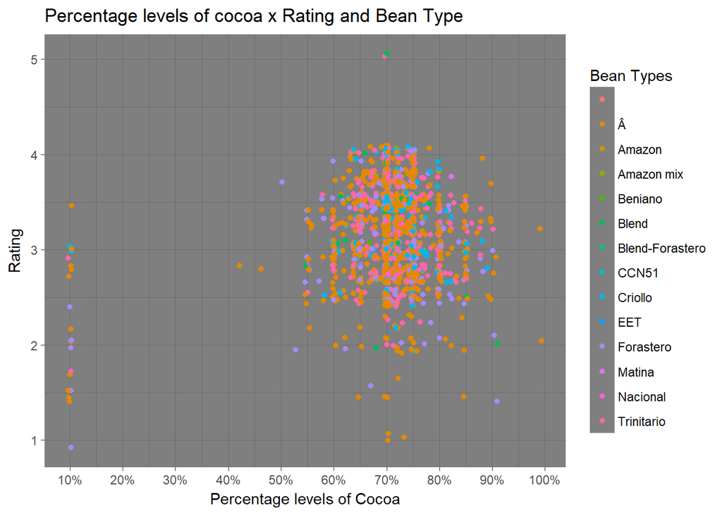

> This chart shows the percentage levels of cocoa vs the Rating. There is a concentration of points around the percentage of 70%. This means the percentage of 70% is the most important and qualified for chocolate processing

# Countries and respective rating levels

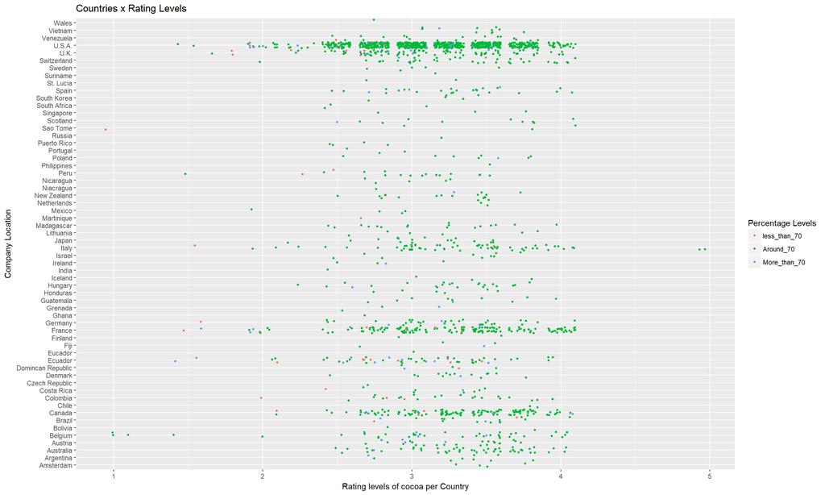

> The chart above shows the best rating are for chocolate percentage between 0.65-0.80

# Correlation factor between percentage of cocoa and cocoa rating

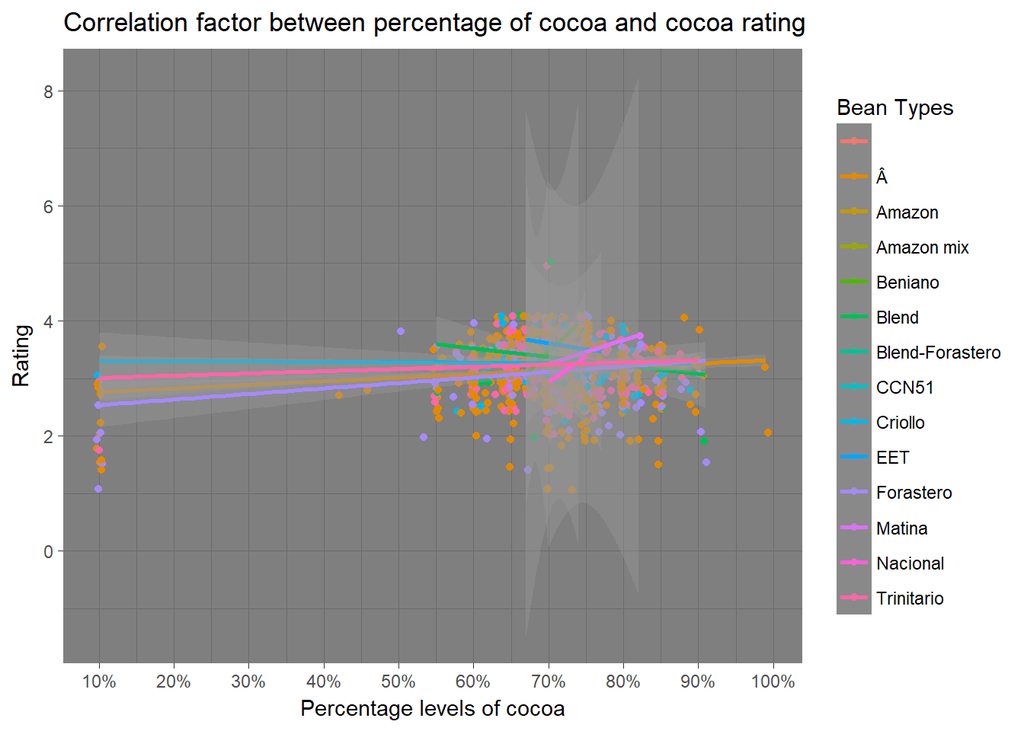

```
##
##  Pearson's product-moment correlation
##
## data:  as.numeric(substr(as.character(cho$Cocoa.Percent), 0, 2)) and cho$Rating
## t = 4.6203, df = 1793, p-value = 4.106e-06
## alternative hypothesis: true correlation is not equal to 0
## 95 percent confidence interval:
##  0.06251601 0.15396309
## sample estimates:
##      cor
## 0.108469
```

# Combining Mean Rating, Rating, cocoa percent and Company

> Items to consider: Rates > 3 Percentage between 65-75

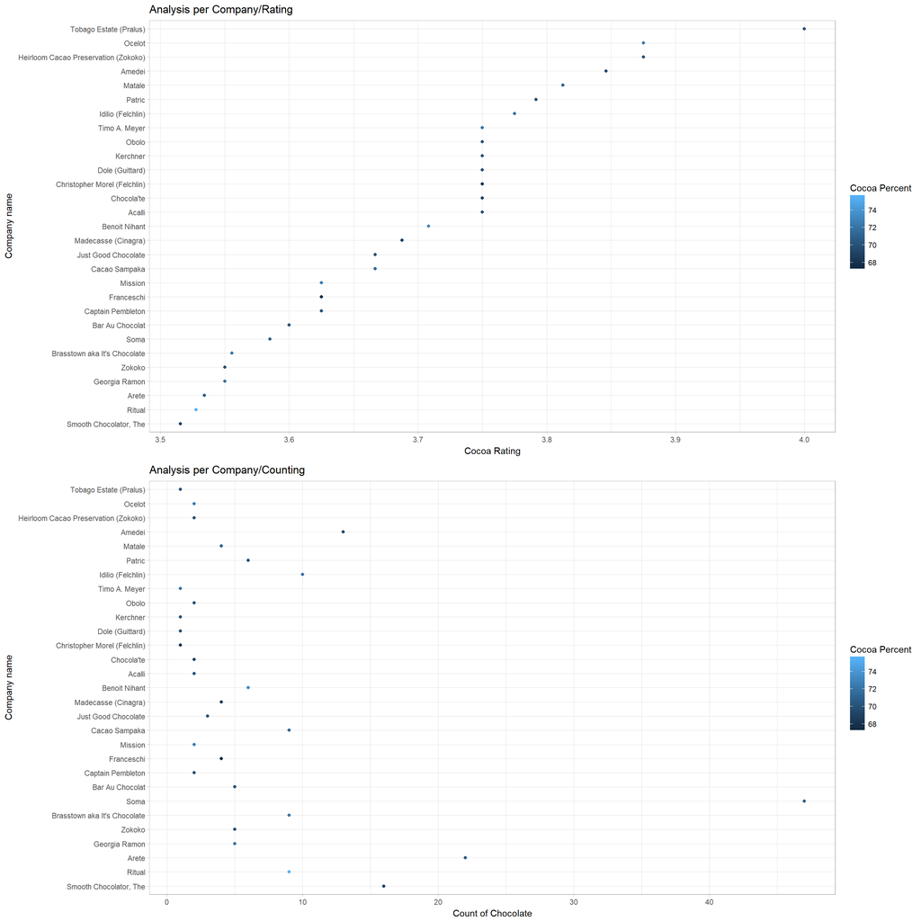

> From the plot above we can see that the company Tobago Estate has comparing to Soma company less samples, but these samples has higher rating. So Soma has appearead before also because it has more quantities of samples comparing to Tobago Estate.

# Multivariate Analysis

### Talk about some of the relationships you observed in this part of the investigation. Were there features that strengthened each other in terms of looking at your feature(s) of interest?

> We can perceive after investigating all the plots that when the chocolate has the percentage levels closer to 70% , the rating level are closer to the best. Probably this percentage is the preferred for the best brands for processing. The 70% chocolate is a pure chocolate and cocoa butter.

### Were there any interesting or surprising interactions between features?

> The surprise was to see countries like Belgium with lower rates. Later I noticed that such lower rates probably is related to the type of cocoa and its type of use. Probably is a low quality cocoa destinated to be used to produce chocolate derivatives such as chocolate sprinkles and liquor.

### OPTIONAL: Did you create any models with your dataset? Discuss the strengths and limitations of your model.

> No. I don’t. There were no such many numeric variables that I could related. The only numeric and important variables were the percentage of cocoa and rating. The most of all data are qualitative and not quantitative. And the unique variable that has an interval of linear relation is the cocoa percent x rating (at the interval of 65-85%)

# Final Plots and Summary

> **Tip**: You’ve done a lot of exploration and have built up an understanding of the structure of and relationships between the variables in your dataset. Here, you will select three plots from all of your previous exploration to present here as a summary of some of your most interesting findings. Make sure that you have refined your selected plots for good titling, axis labels (with units), and good aesthetic choices (e.g. color, transparency). After each plot, make sure you justify why you chose each plot by describing what it shows.

### Plot One

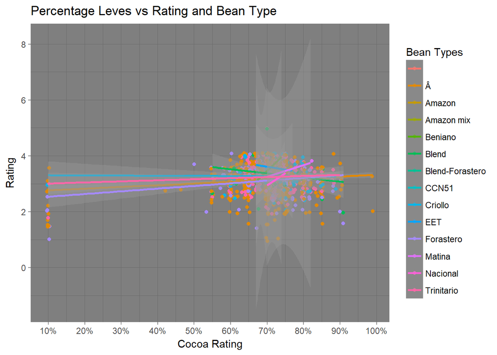

### Description One

> This plot shows the correlation factor between the rating and percentage of Cocoa. For low rate levels there is linear correlation between these values. But at range of 65-75% the correlation is closer and the rating levels are better.

### Plot Two

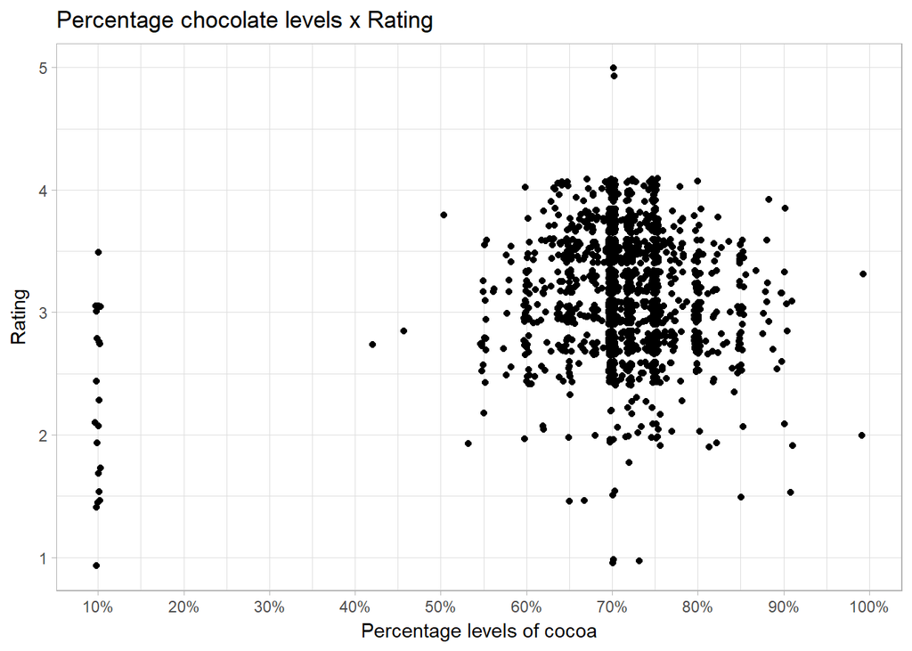

### Description Two

> This plot shows that the best ratings and samples collected are around 70%. This results shows that most of all companies prefers to have chocolates with cocoa percent around 70%

### Plot Three

[figure not shown]

# Reflection